# Introduction to Data Science HW 4

##### Copyright Jeffrey Stanton, Jeffrey Saltz, and Jasmina Tacheva

```r
# Enter your name here: Ryan Brown
```

### Attribution statement: (choose only one and delete the rest)

```r
# 1. I did this homework by myself, with help from the book and the professor.
```

Reminders of things to practice from previous weeks:  
Descriptive statistics: mean( ) max( ) min( )  
Coerce to numeric: as.numeric( )

## Part 1: Use the Starter Code

Below, I have provided a starter file to help you.

Each of these lines of code **must be commented** (the comment must that explains what is going on, so that I know you understand the code and results).

```r
library(tidyverse)
library(jsonlite)
dataset <- url("https://intro-datascience.s3.us-east-2.amazonaws.com/role.json")
readlines <- jsonlite::fromJSON(dataset)
df <- readlines$objects$person
```

1. Explore the **df** dataframe (e.g., using head() or whatever you think is best).

```r
head(df)
```

```
##   bioguideid   birthday cspanid firstname gender gender_label  lastname
## 1    C000880 1951-05-20   26440   Michael   male         Male     Crapo
## 2    G000386 1933-09-17    1167   Charles   male         Male  Grassley
## 3    L000174 1940-03-31    1552   Patrick   male         Male     Leahy
## 4    M001153 1957-05-22 1004138      Lisa female       Female Murkowski
## 5    M001111 1950-10-11   25277     Patty female       Female    Murray
## 6    S000148 1950-11-23    5929   Charles   male         Male   Schumer
##                                                               link middlename
## 1    https://www.govtrack.us/congress/members/michael_crapo/300030         D.
## 2 https://www.govtrack.us/congress/members/charles_grassley/300048         E.
## 3    https://www.govtrack.us/congress/members/patrick_leahy/300065         J.
## 4   https://www.govtrack.us/congress/members/lisa_murkowski/300075         A.
## 5     https://www.govtrack.us/congress/members/patty_murray/300076
## 6  https://www.govtrack.us/congress/members/charles_schumer/300087         E.
##                                   name namemod nickname      osid pvsid
## 1     Sen. Michael “Mike” Crapo [R-ID]             Mike N00006267 26830
## 2 Sen. Charles “Chuck” Grassley [R-IA]            Chuck N00001758 53293
## 3            Sen. Patrick Leahy [D-VT]                  N00009918 53353
## 4           Sen. Lisa Murkowski [R-AK]                  N00026050 15841
## 5             Sen. Patty Murray [D-WA]                  N00007876 53358
## 6  Sen. Charles “Chuck” Schumer [D-NY]            Chuck N00001093 26976
##                                  sortname     twitterid           youtubeid
## 1     Crapo, Michael “Mike” (Sen.) [R-ID]     MikeCrapo        senatorcrapo
## 2 Grassley, Charles “Chuck” (Sen.) [R-IA] ChuckGrassley    senchuckgrassley
## 3            Leahy, Patrick (Sen.) [D-VT]  SenatorLeahy SenatorPatrickLeahy
## 4           Murkowski, Lisa (Sen.) [R-AK] LisaMurkowski    senatormurkowski
## 5             Murray, Patty (Sen.) [D-WA]   PattyMurray  SenatorPattyMurray
## 6  Schumer, Charles “Chuck” (Sen.) [D-NY]    SenSchumer      SenatorSchumer
```

2. Explain the dataset  
   o What is the dataset about?  
   o How many rows are there and what does a row represent?  
   o How many columns and what does each column represent?

```r
summary(df)
```

```
##   bioguideid          birthday            cspanid         firstname
##  Length:100         Length:100         Min.   :    260   Length:100
##  Class :character   Class :character   1st Qu.:  25277   Class :character
##  Mode  :character   Mode  :character   Median :  68489   Mode  :character
##                                        Mean   : 584001
##                                        3rd Qu.:1004138
##                                        Max.   :9269028
##                                        NA's   :11
##     gender          gender_label         lastname             link
##  Length:100         Length:100         Length:100         Length:100
##  Class :character   Class :character   Class :character   Class :character
##  Mode  :character   Mode  :character   Mode  :character   Mode  :character
##
##
##
##
##   middlename            name             namemod            nickname
##  Length:100         Length:100         Length:100         Length:100
##  Class :character   Class :character   Class :character   Class :character
##  Mode  :character   Mode  :character   Mode  :character   Mode  :character
##
##
##
##
##      osid              pvsid             sortname          twitterid
##  Length:100         Length:100         Length:100         Length:100
##  Class :character   Class :character   Class :character   Class :character
##  Mode  :character   Mode  :character   Mode  :character   Mode  :character
##
##
##
##
##   youtubeid
##  Length:100
##  Class :character
##  Mode  :character
##
##
##
##
```

```r
nrow(df)
```

```
## [1] 100
```

```r
ncol(df)
```

```
## [1] 17
```

C. What does running this line of code do? Explain in a comment:

```r
vals <- substr(df$birthday,1,4)
str(vals)
```

```
##  chr [1:100] "1951" "1933" "1940" "1957" "1950" "1950" "1934" "1949" "1950" ...
```

```r
#This line is just taking the birth-year from the birthday field.
```

D. Create a new attribute ‘age’ - how old the person is **Hint:** You may need to convert it to numeric first.

```r
numVals <- as.numeric(vals)
str(numVals)
```

```
##  num [1:100] 1951 1933 1940 1957 1950 ...
```

```r
age <- 2022 - numVals
str(age)
```

```
##  num [1:100] 71 89 82 65 72 72 88 73 72 72 ...
```

E. Create a function that reads in the role json dataset, and adds the age attribute to the dataframe, and returns that dataframe

```r
df <- data.frame(df,age)
head(df$age)
```

```
## [1] 71 89 82 65 72 72
```

F. Use (call, invoke) the function, and store the results in df

## Part 2: Investigate the resulting dataframe ‘df’

1. How many senators are women?

```r
df %>% filter(gender_label == "Female") %>%nrow()
```

```
## [1] 24
```

2. How many senators have a YouTube account?

```r
df %>% filter(youtubeid !=1) %>% tally()
```

```
##    n
## 1 73
```

3. How many women senators have a YouTube account?

```r
df %>% filter(youtubeid !=1, gender=="female") %>% tally()
```

```
##    n
## 1 16
```

4. Create a new dataframe called **youtubeWomen** that only includes women senators who have a YouTube account.

```r
youtubeWomen <- df %>% filter(youtubeid !=1, gender=="female")

youtubeWomen
```

```
##    bioguideid   birthday cspanid firstname gender gender_label   lastname
## 1     M001153 1957-05-22 1004138      Lisa female       Female  Murkowski
## 2     M001111 1950-10-11   25277     Patty female       Female     Murray
## 3     D000622 1968-03-12   94484     Tammy female       Female  Duckworth
## 4     C000127 1958-10-13   26137     Maria female       Female   Cantwell
## 5     F000062 1933-06-22   13061    Dianne female       Female  Feinstein
## 6     S000770 1950-04-29   45451    Debbie female       Female   Stabenow
## 7     B001230 1962-02-11   57884     Tammy female       Female    Baldwin
## 8     B001243 1952-06-06   31226    Marsha female       Female  Blackburn
## 9     H001042 1947-11-03   91216     Mazie female       Female     Hirono
## 10    G000555 1966-12-09 1022862   Kirsten female       Female Gillibrand
## 11    K000367 1960-05-25   83701       Amy female       Female  Klobuchar
## 12    S001191 1976-07-12   68489   Kyrsten female       Female     Sinema
## 13    W000817 1949-06-22 1023023 Elizabeth female       Female     Warren
## 14    F000463 1951-03-01 1034067       Deb female       Female    Fischer
```

[output cut: 53 more lines]

5. Make a histogram of the **age** of senators in **youtubeWomen**, and then another for the senetors in **df**. Add a comment describing the shape of the distributions.

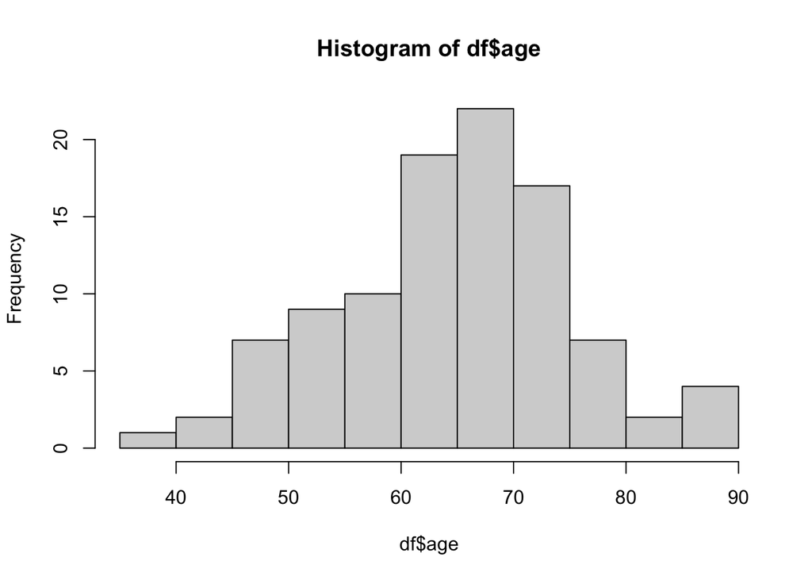

```r
hist(df$age)
```

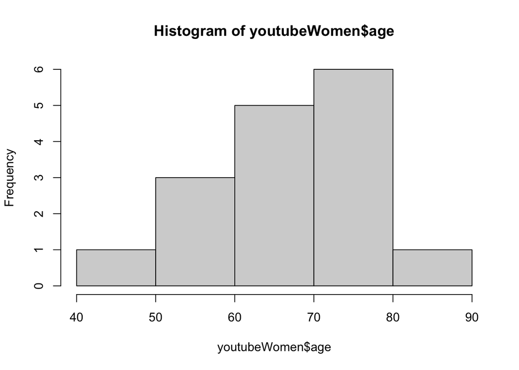

```r
hist(youtubeWomen$age)
```